# Visual Studio Community 2017 のインストール手順

## はじめに

本手順は、書籍『新・標準プログラマーズライブラリ なるほどなっとくC#入門』(技術評論社)の読者のための補助資料として公開するものです。

本文では説明できなかった、Visual Studio Community 2017 のインストール方法について説明しています。

Visual Studio Community 2017は個人開発者や教育、学術研究用に無償で提供されるソフトウェアです。商用利用においては制限がありますので、[ライセンス条項](https://visualstudio.microsoft.com/ja/license-terms/mlt553321/)をお確かめの上、インストールしてください。

## Visual Studioインストール用プログラムをダウンロードし起動する

1. 以下のページにアクセスします。

   [Visual Studio Downloads](https://visualstudio.microsoft.com/ja/downloads)
2. ページを下にスクロールすると、Visual Studio 2017のダウンロードコーナーが現れます。ここの[コミュニティ]ボタンをクリックします。

[figure not shown]

   例えば、Edgeの場合は、以下のようなダイアログが表示されますので、[保存]を選択し、プログラムをディスクに保存します。

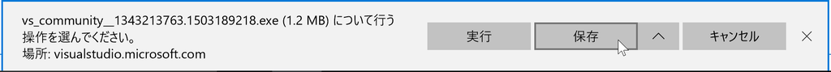

3. ファイルをダウンロードしたら、ダウンロードしたプログラムを実行します。例えば、Edgeの場合は、以下のようなダイアログが表示されますので、[実行]を選択します。

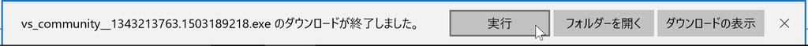

## Visual Studioのインストールを開始する

4. ユーザーアカウント制御のダイアログが表示された場合は、[はい]をクリックします。

[figure not shown]

5. 「プライバシーに関する声明」と「Microsoftソフトウェアのライセンス条項」の確認を求められますので、確認した後、[続行]ボタンをクリックします。

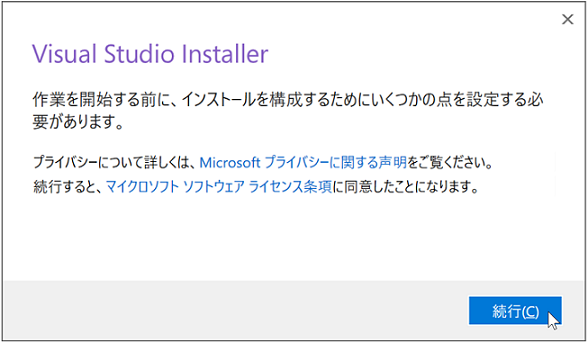

6. Visual Studio Installerのダウンロードとインストールが開始されます。

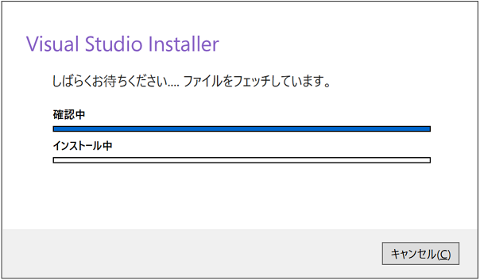

## ワークロードを選択する

7. インストーラーが起動すると、ワークロードの選択画面が表示されます。この画面で、Visual Studioでどのような開発を行うかを指定します。

[figure not shown]

   例えば、Windows用のデスクトップアプリケーションの開発を行うならば「.NET デスクトップ開発」をチェックします。Webアプリケーションの開発を行う場合は「ASP.NETとWeb開発」をチェックします。ワークロードは複数選択することが可能です。

   なお、書籍『新・標準プログラマーズライブラリ なるほどなっとくC#入門』に掲載されているプログラムコードを動かすには、「.NET デスクトップ開発」にチェックを入れてください。このワークロードはインストール後に追加することもできます[^1]。
8. 必要なワークロードを選択したら、画面右下の[インストール]ボタンをクリックします。

[figure not shown]

9. インストールか開始されます。Visual Studio のインストールの進行状況が示されます。インストールに要する時間は、選択するワークロードの数、コンピュータの性能、ネットワークの回線速度などにより異なってきます。環境によってはインストールに1時間以上かかる場合もあります。

[figure not shown]

## Visual Studio にサインインする

10. インストールが完了すると、自動的にVisual Studio が起動し「ようこそ」の画面が表示されます。

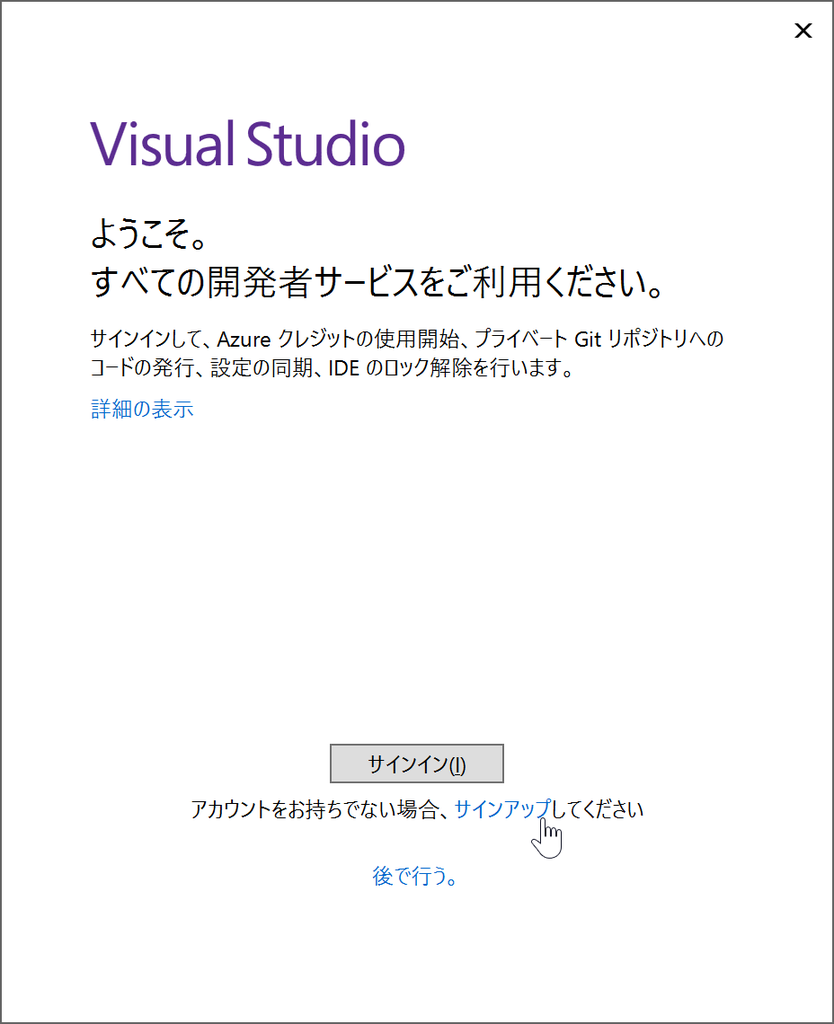

    Microsoftアカウントをお持ちの方は、[サインイン]ボタンを押して、サインインして15へ進んでください。

    Microsoftアカウントをお持ちで無い方は、[サインアップ]のリンクをクリックしてください。
11. アカウント作成のウィンドウが表示されますので、ここで、あなたのメールアドレスを入力し、[次へ]ボタンをクリックします。

[figure not shown]

12. 次にパスワード作成のウインドウで、Microsoftアカウントのパスワードを入力し、[次へ]ボタンをクリックします。

[figure not shown]

13. 11で入力したメールアドレスにメールが届きます。メールに記載されている確認コードを入力し、[次へ]ボタンをクリックします。

[figure not shown]

14. アカウントの作成ウインドウが表示されます。画像に表示されている英数字の文字を入力欄に入力し、[次へ]ボタンをクリックします。

[figure not shown]

15. サインインが完了すると、下記のウインドウが表示されます。配色テーマの選択をし、[Visual Studioの開始]ボタンをクリックします。

[figure not shown]

16. Visual Studioが起動し、C#での開発が行えるようになります。

[figure not shown]

以上でインストールは完了です。

[^1]: ワークロードを後から追加するには、スタートメニューから[Visual Studio Installer]を開きます。 ここで、インストールするワークロードを選択し[変更]をクリックします。